# Overview

# Foreword

Waterbody Information Packs (WIPs) and associated Action Plans were introduced by the Environment Planning Team to look at priority waterbodies that were scheduled for delivery by 2015 in the first River Basin Management Plan. They have provided a basis for identifying measures to deliver Good Ecological Status in our target waterbodies.

In light of our experience with this way of working and in accordance with guidance from DEFRA and the Environment Agency, it has been decided that we should look at improvements for Water Framework Directive in the next cycle on a catchment wide scale with particular reference to working in partnership with other organizations where this can help deliver the required outcomes.

# Geography of Catchment

The Brue and Axe sits within the Somerset South and West management catchment, which sits within the larger South West River Basin District.

It contains 25 individual EA waterbodies: Pitt, Brue - R Pitt to R Alham, Coxbridge Brook( Brue), Brue - Upper, Alham, Hartlake, Redlake, Whitelake, South Drain, Brue - Tootle Bridge to Clyse Hole, Brue - R. Alham to Tootle Bridge, Brue - Clyce Hole to conf North Drain, North Drain, Huntspill, Sheppey, Keward Brook, Mark Yeo, Brue - conf with North Drain to Tidal Limit, Shipham Rhyne (Trib of Brue/Cripps), Axe - source to Cocklake, Pitland Rhyne - source to conf R Axe, Cheddar Yeo - source to conf River Axe, Axe - Cocklake to Brean Cross Sluice, Lox Yeo - source to conf Rive Axe, Uphill Great Rhyne - source to conf R Axe Estuary

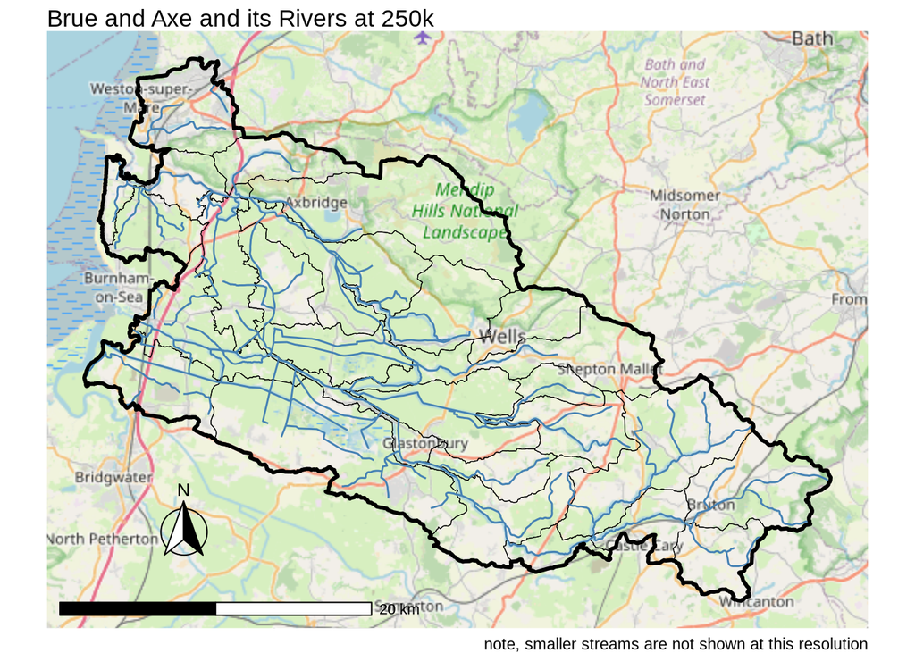

Catchment and its rivers at 250k

# Geological Map of Catchment

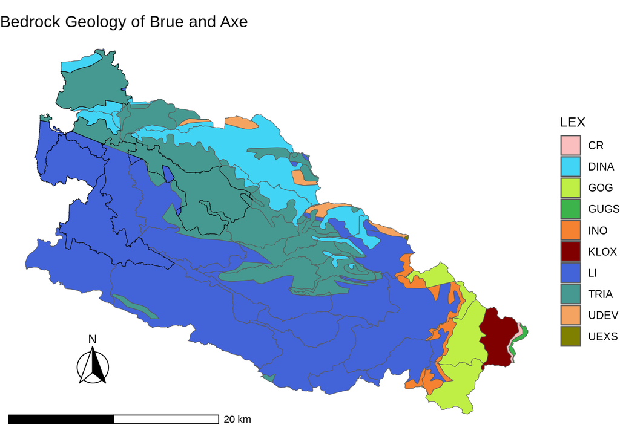

# Topography

[figure not shown]